# Estimates of Methow Steelhead Redds and Spawners

Spawn Year 2022

Kevin See<sup>1,✉</sup>

January 20, 2023

Abstract

This report contains estimates of total steelhead redds in the Methow, after accounting for observer error. It also includes estimates of spawners, as well as prespawn mortality.

<sup>1</sup> Washington Department of Fish & Wildlife

<sup>✉</sup> Correspondence: Kevin See <Kevin.See@dfw.wa.gov>

# 1 Introduction

Redd counts are an established method to provide an index of adult spawners (Gallagher et al. 2007). In the Methow subbasin, index reaches are surveyed weekly during the steelhead spawning season (Mar 09, 2022 - May 11, 2022) and non-index reaches are surveyed once during the peak spawning period. The goal of this work is to:

1. Predict observer net error, using the model described in Murdoch et al. (2018).
2. Use estimates of observer net error rates and the mean survey interval to estimate the number of redds in each index reach, using a Gaussian area under the curve (GAUC) technique described in Millar et al. (2012) and Murdoch et al. (2018).
3. Estimate the total number of redds in the non-index reaches by adjusting the observed counts with the estimated net error where possible.
4. Sum the total number of estimated redds for the entire Methow subbasin.
5. Translate the estimated number of redds into estimates of spawners, by origin.

# 2 Methods

## 2.1 Net Error Model

The net error ($NE$) for a reach $i$ is defined as

$$NE_i = \frac{F_i}{V_i}$$

where $F_i$ is the number of redds the surveyor reported and $V_i$ is the true number of redds in the reach. Therefore, if we have an estimate of net error ($\hat{NE_i}$), we can calculate the true number of redds based on that estimate and the number of redds the surveyor reported:

$$\begin{equation}
V_i = \frac{F_i}{\hat{NE_i}}
\tag{2.1}
\end{equation}$$

The model for observer net error is fully described in Murdoch et al. (2018). It uses covariates of the log of observer experience, mean discharge, the observed redd density and mean thalweg CV as a proxy for channel complexity. After normalizing these covariates, the model coefficients are shown in Table 2.1. The response, net error, is scaled such that estimates of net error less than 1 suggest more errors of omission, while estimates greater than 1 suggest more errors of commission. An estimate of net error equal to one would indicate the observed count equals the true number of redds.

Table 2.1: Net error model covariates and coefficients.

| Covariate | Estimate | Std. Error |
| --- | --- | --- |
| (Intercept) | 0.682 | 0.039 |
| Obs. Redd Density | 0.277 | 0.053 |
| Mean Thalweg CV | -0.169 | 0.043 |
| Mean Discharge | 0.116 | 0.048 |
| Log Surveyor Exp. | 0.115 | 0.042 |

## 2.2 Data

Redd counts were conducted on a nearly weekly basis for index reaches, and once during the peak spawning period for non-index reaches. The covariates in the observer error model of Murdoch et al. (2018) were collected during each survey. The covariate of mean thalweg CV was calculated based on all measurements taken within a reach across years (assuming this covariate does not vary through time within a reach). They were compared with the covariates contained in the model data set, as well as the estimates of net error (Figure 2.1).

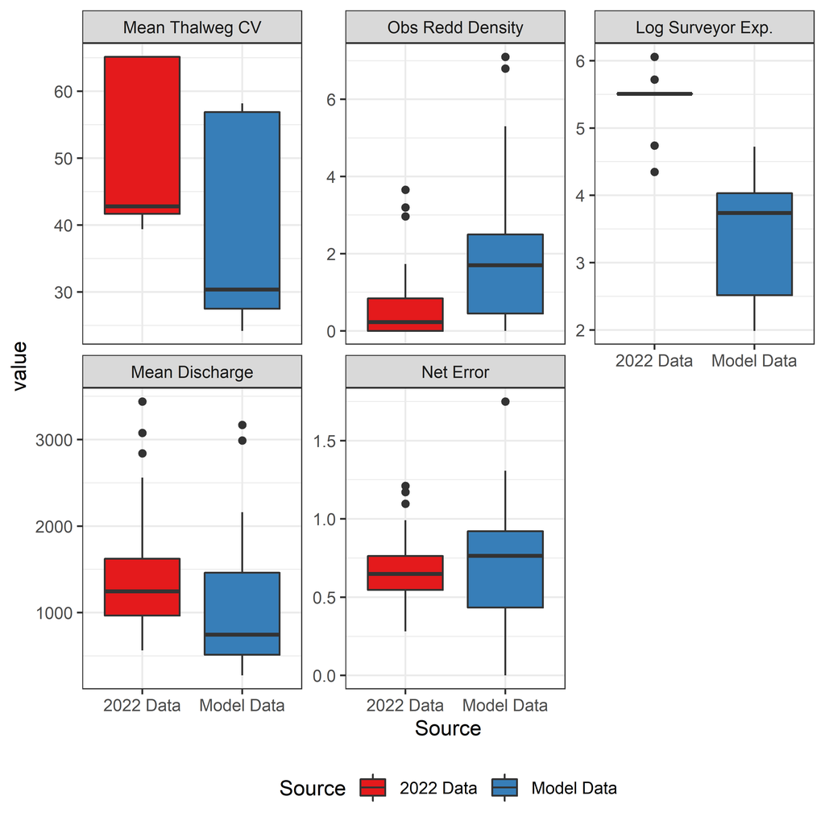

Figure 2.1: Net error covariate values. Colors correspond to either the original study or the reaches where the model was used in this report.

Those covariates in the observer error model were collected during each survey in 2022, and predictions of net error were made for each survey. From these survey specific estimates of net error, a mean and standard error of net error was calculated for each reach. The standard deviation was calculated by taking the square root of the sum of the squared standard errors for all predictions within a reach.

## 2.3 Estimating Redds

Use of the GAUC methodology was limited to index reaches with a minimum of two redds and at least three weeks with at least one new redd found. For those reaches, we used the method described in Millar et al. (2012) and Murdoch et al. (2018). The GAUC model was developed with spawner counts in mind. As it is usually infeasible to mark every individual spawner, only total spawner counts can be used, and an estimate of average stream life must be utilized to translate total spawner days to total unique spawners. However, in adapting this for redd surveys, we note that individual redds can be marked, and therefore the GAUC model can be fit to new redds only. The equivalent of stream life is thus the difference between survey numbers, which can be fixed at 1. We applied the average net error from all the surveys when redds were visible, so as to not bias the estimate from early weeks when no redds were found, and the observed redd density was zero.

For non-index reaches, which were surveyed only once during peak spawning, the estimate of total redds was calculated by dividing the observed redds by the estimate of net error associated with that survey (Eq. (2.1)). This assumes that no redds were washed out before the non-index survey, and that no new redds appeared after that survey. As the number of redds observed in the non-index reaches ranged from 8 to 24, any violation of this assumption should not affect the overall estimates very much. Any index reaches that did not meet the thresholds described above were treated as non-index reaches, and the total observed redds in those reaches were divided by the mean estimate of net error for each reach.

When summing reach-scale estimates to obtain estimates at the stream scale, an attempt was made to incorporate the fact that the reaches within a stream are not independent. Estimates of correlation between the reaches within a stream were made based on weekly observed redds. This method may not be perfect, since spawners could use certain reaches preferentially at different times in the season, but it may be the best we can do. Because correlations are often quite high between reaches, this is a better alternative than to naively assume the standard errors between reaches are independent of one another. These correlation estimates were combined with estimates of standard error at the reach scale to calculate a covariance matrix for the reaches within each stream, which was used when summing estimates of total redds to estimate the standard error at the stream scale. Failure to incorporate the correlations between reaches would result in an underestimate of standard error at the stream scales. Different streams (and therefore reaches in different streams) were assumed to be independent.

## 2.4 Estimating Spawners

Estimates of escapement to various tributaries in the Methow were made using a Dam Adult Branch Occupancy Model (DABOM) (Waterhouse et al. 2020) based on PIT tag detections of fish tagged at Priest Rapids dam. All fish that escaped to the various tributaries were assumed to be spawners (i.e. prespawn mortality only occurs in the mainstem). Reaches below the PIT tag arrays in some tributaries were surveyed for redds, but we assumed there was no observer error in those reaches.

To convert estimates of redds in mainstem areas into estimates of natural and hatchery spawners, the estimates of redds were multiplied by a fish per redd (FpR) estimate and then by the proportion of hatchery or wild fish. The fish per redd estimate was based on PIT tags from the branching patch-occupancy model observed to move into the lower mainstem Methow, but not into tributaries (between PTAGIS sites LMR and MRW). FpR was calculated as the ratio of male to female fish, plus 1. Reaches MRW1 - MRW8 are all in the lower mainstem Methow below Winthrop. Similarly, the proportion of hatchery and natural origin fish was calculated from the same group of PIT tags for areas in the mainstem, and the various tributaries. For reaches in tributaries below the tributary PIT tag array, FpR and the proportion hatchery were calculated based on observed PIT tags moving into the lower regions of each tributary. For the reach just below the Methow hatchery outfall, we used FpR and pHOS from Spring Creek (SCP), because they are both hatchery channels of a similar water source in close proximity to each other.

Within the Methow, there are two types of hatchery fish: safety net (HOR-SN) and conservation (HOR-C). These are distinguished by different marks. Safety net fish are ad-clipped but do not have a coded wire tag (CWT), whereas conservation fish may or may not be ad-clipped, but do have a CWT implanted. Fish determined to be hatchery (from scales), but were not designated as ad-clipped or having a CWT were considered conservation fish.  
For 2022, we noticed a discrepancy in the sex calls at Priest Rapids and the sex calls from broodstock collection at Wells Hatchery and in the Wenatchee. Therefore, we developed a correction factor that accounts for the error rate in female and male calls independently, and adjusts the fish / redd estimate accordingly. The error rate of sex calls at Priest are shown in Appendix A in Table A.1.

## 2.5 Prespawn Mortality

After translating estimates of redds to estimates of spawners by origin, we can then compare the spawner estimates to escapement estimates made using PIT tags, and estimate a prespawn mortality rate. Taking the total PIT-tag based escapement estimate, by origin, to the Methow, we then subtract any fish removed for broodstock or surplus, as well as any deaths due to harvest (Table 2.2), and then subtract the total estimate of spawners, including the tributaries, to provide an estimate of how many fish succumbed to prespawn mortality. Dividing that number by the total escapement estimate provides an estimate of the prespawn mortality rate, by origin, across the entire Methow population.

Table 2.2: Known number of fish removed at for surplus or broodstock, or due to harvest, by origin.

| Source | Hatchery | Natural |
| --- | --- | --- |
| Methow mainstem | 163 | 95 |
| DCPUD to Wells | 5 | 0 |
| Twisp weir | 12 | 10 |
| WNFH hatchery trap | 0 | 0 |

If either origin had a higher estimates of spawners compared to escapement, we fixed our prespawn mortality estimate at 0, reflecting a very low level of prespawn mortality. There is uncertainty in both the escapement and spawner estimates, which could explain why these types of scenarios could arise.

# 3 Results

## 3.1 Redd estimates

The estimated net error, observed redds and estimates of redds at the reach scale are shown in Table 3.1. Plots of the new redds and the GAUC fit to those data are shown in Figure 3.1. The results are summarized by major areas and population scale in Table 3.2.

Table 3.1: Estimates of mean net error and redds for each reach.

| River | Reach | Type | Net Error | Net Error CV | Observed Redds | Estimated Redds | Std. Err. Redds | Redds CV |
| --- | --- | --- | --- | --- | --- | --- | --- | --- |
| Methow | MRW1 | Non-Index | 1 | 0 | 8 | 8 | 0 | 0 |
| Methow | MRW2 | Index | 0.46 | 0.378 | 19 | 45 | 25.1 | 0.557 |
| Methow | MRW3 | Non-Index | 1 | 0 | 24 | 24 | 0 | 0 |
| Methow | MRW4 | Index | 0.947 | 0.122 | 20 | 21 | 4.6 | 0.218 |
| Methow | MRW5 | Non-Index | 1 | 0 | 9 | 9 | 0 | 0 |
| Methow | MRW6 | Index | 0.813 | 0.165 | 8 | 10 | 2.7 | 0.273 |
| Methow | MRW7 | Non-Index | 1 | 0 | 17 | 17 | 0 | 0 |
| Methow | MRW8 | Index | 0.676 | 0.199 | 4 | 6 | 3.1 | 0.523 |
| Methow Fish Hatchery | MH1 | Tributary | 1 | 0 | 6 | 6 | 2 | 0.326 |
| Spring Creek | WN1 | Tributary | 1 | 0 | 28 | 29 | 6.3 | 0.216 |
| Twisp | T1 | Tributary | 1 | 0 | 8 | 8 | 1.8 | 0.226 |

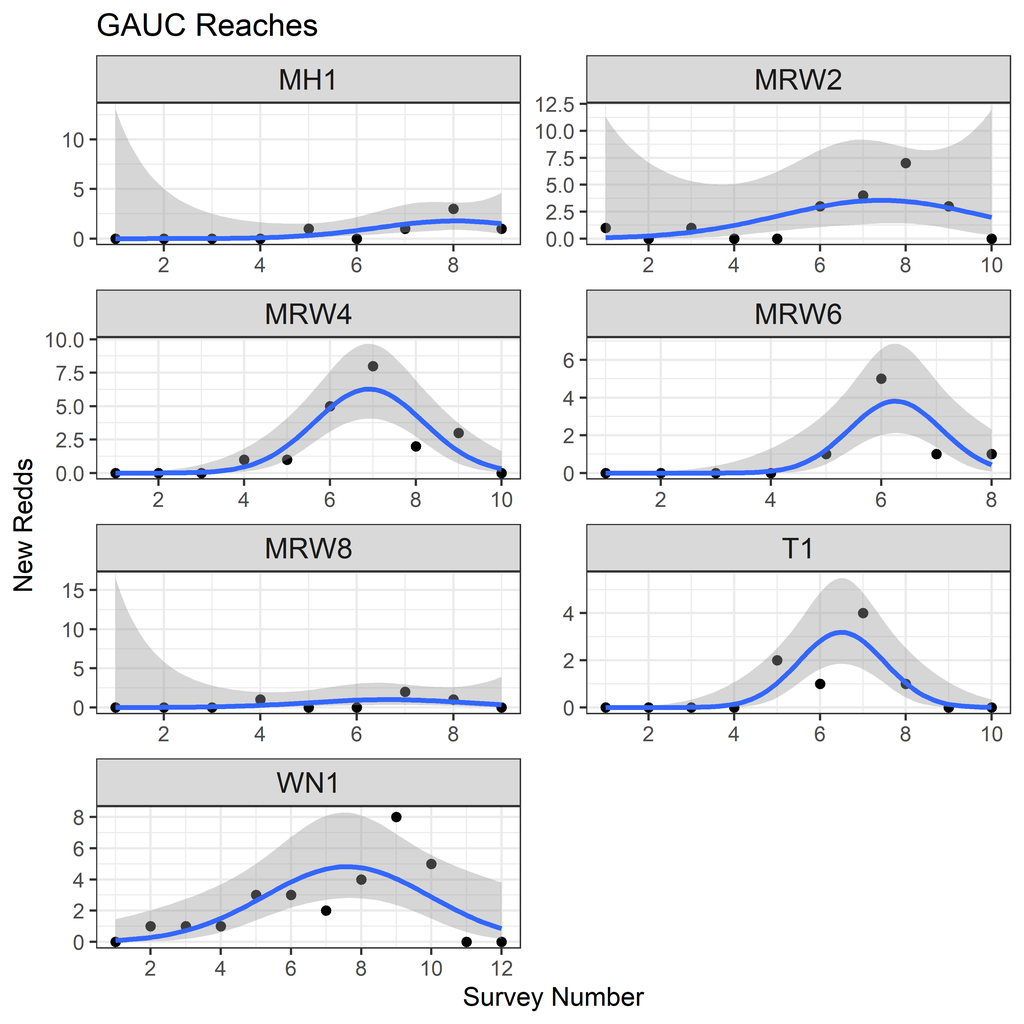

Figure 3.1: Plots of observed redd counts (black dots) through time for each qualifying index reach, and the fitted curve from the GAUC model (blue line) with associated uncertainty (gray).

Table 3.2: Estimate of redds in lower mainstem Methow, and any tributaries surveyed.

River

Location

Type

# Reaches

Observed Redds

Estimated Redds

Std. Err. Redds

Redds CV

Methow

Lower Methow

Non-Index

4

58

58

0

0

Methow

Lower Methow

Index

4

51

82

25.8

0.315

Methow Fish Hatchery

Tributary

Tributary

1

6

6

2

0.326

Spring Creek

Tributary

Tributary

1

28

29

6.3

0.216

Twisp

Tributary

Tributary

1

8

8

1.8

0.226

Total

11

151

183

26.7

0.146

## 3.2 Spawner Estimates

Demographic data about sex and origin were derived from the PIT tags detected within each area (Table 3.3.

Table 3.3: Number of PIT tags detected in each area by sex and origin.

| Location | Sex | Natural | HOR-SN | HOR-C |
| --- | --- | --- | --- | --- |
| Lower Methow | F | 27 | 38 | 9 |
| Lower Methow | M | 4 | 10 | 2 |
| Upper Methow | F | 3 | 1 | 0 |
| Upper Methow | M | 1 | 0 | 0 |
| Chewuch | F | 8 | 3 | 1 |
| Chewuch | M | 1 | 1 | 0 |
| Twisp | F | 10 | 6 | 3 |
| Twisp | M | 1 | 0 | 2 |
| Spring Creek | F | 1 | 9 | 6 |
| Spring Creek | M | 0 | 5 | 1 |
| Beaver | F | 2 | 3 | 1 |
| Beaver | M | 0 | 0 | 0 |
| Gold | F | 2 | 4 | 0 |
| Gold | M | 0 | 2 | 0 |
| Libby | F | 0 | 2 | 0 |
| Libby | M | 0 | 0 | 0 |

Parameter estimates for fish / redd and proportion hatchery based on this PIT tag data are shown in Table 3.4.

Table 3.4: Fish per redd and hatchery / natural origin proportion estimates.

| Location | Fish / redd | FpR Std. Error | Prop. Hatchery | Prop Std. Error |
| --- | --- | --- | --- | --- |
| Lower Methow | 2.647 | 0.319 | 0.656 | 0.050 |
| Twisp | 2.444 | 0.282 | 0.500 | 0.107 |
| Spring Creek | 3.143 | 0.411 | 0.955 | 0.044 |

Table 3.5 shows estimates of spawners by origin within each reach of the lower Methow, including reaches in tributaries below the PIT tag array. Combining those adjusted redd-based estimates of spawners with PIT tag-based estimates of spawners in the tributaries, Table 3.6 shows a summary of spawners by origin across various areas including the lower Methow mainstem and each tributary, as well as the population as a whole.

Table 3.5: Estimates (CV) of spawners in lower Methow by reach and origin.

Location

Reach

Type

Total Spawners

Natural

HOR-SN

HOR-C

Lower Methow

MRW1

Non-Index

21 (0.12)

7 (0.19)

11 (0.16)

3 (0.31)

Lower Methow

MRW2

Index

120 (0.57)

41 (0.59)

64 (0.58)

15 (0.64)

Lower Methow

MRW3

Non-Index

64 (0.12)

22 (0.19)

34 (0.16)

8 (0.31)

Lower Methow

MRW4

Index

56 (0.25)

19 (0.29)

30 (0.27)

7 (0.38)

Lower Methow

MRW5

Non-Index

24 (0.12)

8 (0.19)

13 (0.16)

3 (0.31)

Lower Methow

MRW6

Index

26 (0.3)

9 (0.33)

14 (0.31)

3 (0.41)

Lower Methow

MRW7

Non-Index

46 (0.12)

16 (0.19)

24 (0.16)

6 (0.31)

Lower Methow

MRW8

Index

15 (0.54)

5 (0.56)

8 (0.55)

2 (0.61)

Methow Fish Hatchery

MH1

Tributary

19 (0.35)

1 (1.04)

12 (0.39)

6 (0.47)

Spring Creek

WN1

Tributary

91 (0.25)

4 (1.01)

58 (0.3)

29 (0.4)

Twisp

T1

Tributary

19 (0.25)

10 (0.33)

5 (0.43)

4 (0.47)

Total

501 (0.15)

142 (0.19)

273 (0.16)

86 (0.19)

Table 3.6: Estimates (CV) of spawners by area and origin.

| River | Total Spawners | Natural | HOR-SN | HOR-C |
| --- | --- | --- | --- | --- |
| Lower Methow | 371 (0.19) | 128 (0.2) | 198 (0.2) | 45 (0.23) |
| Beaver | 59 (0.1) | 20 (0.67) | 29 (0.57) | 10 (0.99) |
| Chewuch | 122 (0.06) | 74 (0.34) | 38 (0.48) | 10 (0.99) |
| Gold | 82 (0.08) | 23 (0.64) | 59 (0.39) | 0 (-) |
| Libby | 26 (0.17) | 0 (-) | 26 (0.73) | 0 (-) |
| Methow Fish Hatchery | 19 (0.35) | 1 (1.04) | 12 (0.39) | 6 (0.47) |
| Spring Creek | 298 (0.08) | 18 (0.7) | 187 (0.21) | 93 (0.29) |
| Twisp | 204 (0.04) | 99 (0.27) | 57 (0.37) | 48 (0.41) |
| Upper Methow | 57 (0.11) | 41 (0.59) | 16 (1) | 0 (-) |
| Total | 1,238 (0.06) | 404 (0.14) | 622 (0.12) | 212 (0.18) |

## 3.3 Prespawn Mortality

The estimates of overall prespawn mortality within the Methow population, by origin, are shown in Table 3.7.

Table 3.7: Methow prespawn mortality estimates. Includes estimates (standard error) of escapement, spawners, rate of prespawn mortality, and standard error of this rate, separated by origin.

Origin

Escapement

Spawners

Prespawn Mortality

SE

CV

Natural

413 (69)

403 (57)

0.025

0.213

8.388

Hatchery

790 (89)

833 (87)

0.000

# 4 Discussion

Natural origin steelhead PIT-tagged at Priest Rapids dam were not detected in Libby Creek this year, nor were HOR-C fish detected in Gold, Libby or the Upper Methow, leading to estimates of zero spawners for those origins in those tributaries (Table 3.6). Because these estimates are based on a sample of the entire Upper Columbia steelhead run, it’s possible that a low number of steelhead may have spawned in those tributaries, but it’s potentially more likely that the estimate of zero steelhead spawners in those areas is correct.

Some of the estimates of prespawn mortality were zero this year, due to higher estimates of spawners compared to escapement, at least after removals had been accounted for. In all cases, there were overlapping confidence intervals between spawners and escapement, so not too much should be made of that fact, and we interpret that as at least very low levels of prespawn mortality, perhaps even none.

# 5 Acknowledgements

The data for this report was collected by Washington Department of Fish and Wildlife, and funded by Douglas County Public Utility District.

# 6 References

Gallagher, S. P., P. K. J. Hahn, and D. H. Johnson. 2007. Salmonid field protocols handbook: Techniques for assessing status and trends in salmon and trout populations. Pages 197–234 *in* D. H. Johnson, editor. American Fisheries Society, Bethesda, Maryland.

Millar, R. B., S. McKechnie, and C. E. Jordan. 2012. Simple estimators of salmonid escapement and its variance using a new area-under-the-curve method. Canadian Journal of Fisheries and Aquatic Sciences 69(6):1002–1015.

Murdoch, A. R., C. J. Herring, C. H. Frady, K. See, and C. E. Jordan. 2018. Estimating observer error and steelhead redd abundance using a modified gaussian area-under-the-curve framework. Canadian Journal of Fisheries and Aquatic Sciences (999):1–10.

Waterhouse, L., J. White, K. See, A. Murdoch, and B. X. Semmens. 2020. A bayesian nested patch occupancy model to estimate steelhead movement and abundance. Ecological Applications.

# A Sex Errors at Priest Rapids

Fish collected for broodstock at Wells Hatchery and within the Wenatchee had a known sex. Based on PIT tag detections of this broodstock collection, those sexes could be compared with the sex call at Priest when the fish was initially tagged. Assuming that this error rate is systematic across the entire run within a brood year, we combined all tags with this kind of comparison. Table A.1 shows the sample sizes and results.

Table A.1: Error rate in sex calls at Priest Rapids.

| Brood Year | Sex | N Tags | N True | N False | Perc False | Lwr CI | Upr CI |
| --- | --- | --- | --- | --- | --- | --- | --- |
| 2022 | F | 43 | 20 | 23 | 0.535 | 0.389 | 0.675 |
| 2022 | M | 19 | 19 | 0 | 0.000 | 0.000 | 0.168 |

These error rates were used to adjust the counts of male and female tags within particular spawning areas before re-calculating the fish/redd estimate. For example, the adjusted number of males would be the initial number of males, minus the number of initial males times the error rate for male identification, plus the number of initial females times the error rate for female identification.